# CA4_810199457

```python
# Libraries for preprocessing
import nltk
import re

# Scientific libraries
import numpy as np
import pandas as pd
import sklearn as sk
from sklearn import preprocessing

# Data visualization libraries
import seaborn as sns
import matplotlib.pyplot as plt
```

## Phase 0: EDA and visualization

```python
diabetes = pd.read_csv('diabetes.csv')
diabetes.head()
```

|  | Pregnancies | Glucose | BloodPressure | SkinThickness | Insulin | BMI | DiabetesPedigreeFunction | Age | Outcome |
| --- | --- | --- | --- | --- | --- | --- | --- | --- | --- |
| 0 | 6.0 | 148.0 | 72.0 | 35.0 | 0.0 | 33.6 | 0.627 | 50.0 | 1 |
| 1 | 1.0 | 85.0 | 66.0 | 29.0 | 0.0 | 26.6 | 0.351 | 31.0 | 0 |
| 2 | NaN | 183.0 | 64.0 | 0.0 | 0.0 | 23.3 | 0.672 | 32.0 | 1 |
| 3 | 1.0 | 89.0 | 66.0 | 23.0 | 94.0 | 28.1 | 0.167 | 21.0 | 0 |
| 4 | NaN | 137.0 | 40.0 | 35.0 | 168.0 | NaN | NaN | 33.0 | 1 |

Q1.

```python
diabetes.describe()
```

|  | Pregnancies | Glucose | BloodPressure | SkinThickness | Insulin | BMI | DiabetesPedigreeFunction | Age | Outcome |
| --- | --- | --- | --- | --- | --- | --- | --- | --- | --- |
| count | 635.000000 | 654.000000 | 680.000000 | 624.000000 | 680.000000 | 684.000000 | 590.000000 | 655.000000 | 768.000000 |
| mean | 3.700787 | 113.422018 | 68.786765 | 20.386218 | 80.123529 | 32.083626 | 0.466676 | 33.157252 | 0.348958 |
| std | 3.518126 | 202.816831 | 19.724841 | 15.987049 | 115.681140 | 7.800741 | 0.322408 | 13.829831 | 0.476951 |
| min | -22.000000 | -5000.000000 | -2.000000 | 0.000000 | 0.000000 | 0.000000 | 0.078000 | -150.000000 | 0.000000 |
| 25% | 1.000000 | 99.000000 | 62.000000 | 0.000000 | 0.000000 | 27.375000 | 0.243250 | 24.000000 | 0.000000 |
| 50% | 3.000000 | 117.000000 | 72.000000 | 23.000000 | 34.000000 | 32.300000 | 0.368000 | 29.000000 | 0.000000 |
| 75% | 6.000000 | 140.750000 | 80.000000 | 32.000000 | 129.250000 | 36.600000 | 0.611500 | 41.000000 | 1.000000 |
| max | 17.000000 | 199.000000 | 122.000000 | 99.000000 | 846.000000 | 67.100000 | 2.329000 | 81.000000 | 1.000000 |

```python
diabetes.info()
```

```
<class 'pandas.core.frame.DataFrame'>
RangeIndex: 768 entries, 0 to 767
Data columns (total 9 columns):
 #   Column                    Non-Null Count  Dtype
---  ------                    --------------  -----
 0   Pregnancies               635 non-null    float64
 1   Glucose                   654 non-null    float64
 2   BloodPressure             680 non-null    float64
 3   SkinThickness             624 non-null    float64
 4   Insulin                   680 non-null    float64
 5   BMI                       684 non-null    float64
 6   DiabetesPedigreeFunction  590 non-null    float64
 7   Age                       655 non-null    float64
 8   Outcome                   768 non-null    int64
dtypes: float64(8), int64(1)
memory usage: 54.1 KB
```

Q2.

```python
for feature in diabetes:
    print("Number of NaN", feature, ":", diabetes[feature].isnull().sum())
    print("Percentage of NaN", feature, ":", diabetes[feature].isnull().sum() * 100/len(diabetes), "%")
    print("---------------------------------")
```

```
Number of NaN Pregnancies : 133
Percentage of NaN Pregnancies : 17.317708333333332 %
---------------------------------
Number of NaN Glucose : 114
Percentage of NaN Glucose : 14.84375 %
---------------------------------
Number of NaN BloodPressure : 88
Percentage of NaN BloodPressure : 11.458333333333334 %
---------------------------------
Number of NaN SkinThickness : 144
Percentage of NaN SkinThickness : 18.75 %
---------------------------------
Number of NaN Insulin : 88
Percentage of NaN Insulin : 11.458333333333334 %
---------------------------------
Number of NaN BMI : 84
Percentage of NaN BMI : 10.9375 %
---------------------------------
Number of NaN DiabetesPedigreeFunction : 178
Percentage of NaN DiabetesPedigreeFunction : 23.177083333333332 %
---------------------------------
Number of NaN Age : 113
Percentage of NaN Age : 14.713541666666666 %
---------------------------------
Number of NaN Outcome : 0
Percentage of NaN Outcome : 0.0 %
---------------------------------
```

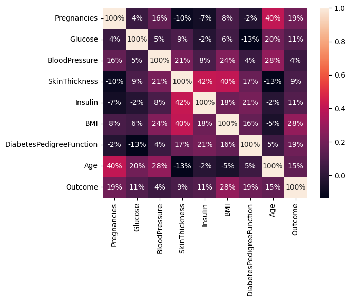

```python
# plt.figure(figsize=(5, 5))
sns.heatmap(diabetes.corr(), annot=True, fmt=".0%")
plt.show()
```

As we see in the plot BMI has the most dependency to outcome.

```python
diabetes.drop(columns=['BloodPressure'], inplace=True)
```

```
array([[<AxesSubplot: title={'center': 'Pregnancies'}>,
        <AxesSubplot: title={'center': 'Glucose'}>,
        <AxesSubplot: title={'center': 'SkinThickness'}>],
       [<AxesSubplot: title={'center': 'Insulin'}>,
        <AxesSubplot: title={'center': 'BMI'}>,
        <AxesSubplot: title={'center': 'DiabetesPedigreeFunction'}>],
       [<AxesSubplot: title={'center': 'Age'}>,
        <AxesSubplot: title={'center': 'Outcome'}>, <AxesSubplot: >]],
      dtype=object)
```

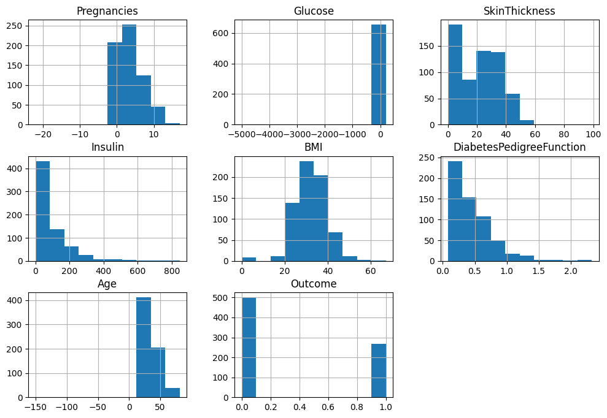

```python
diabetes.hist(figsize=(12, 8))
```

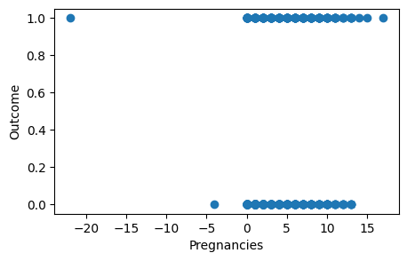

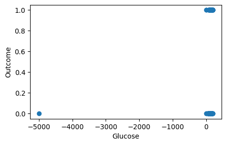

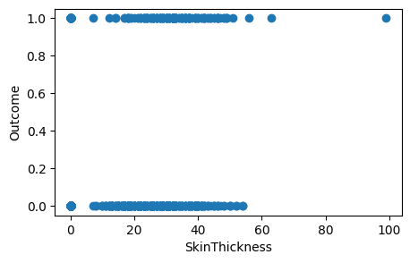

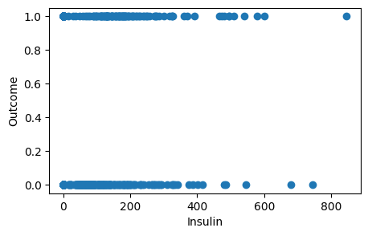

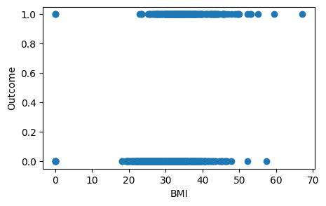

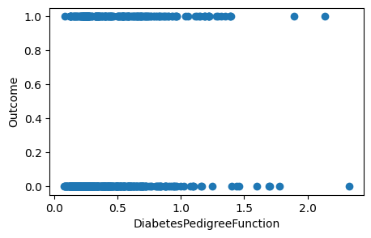

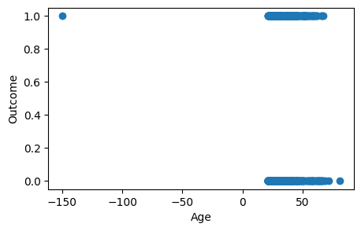

```python
for feature in diabetes:
    if feature != 'Outcome':
        plt.figure(figsize=(5, 3))
        plt.scatter(diabetes[feature], diabetes['Outcome'])
        plt.xlabel(feature)
        plt.ylabel('Outcome')
        plt.show()
```

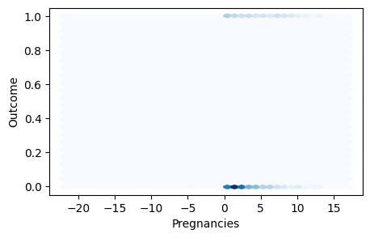

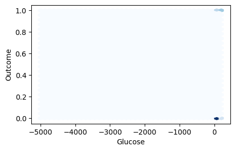

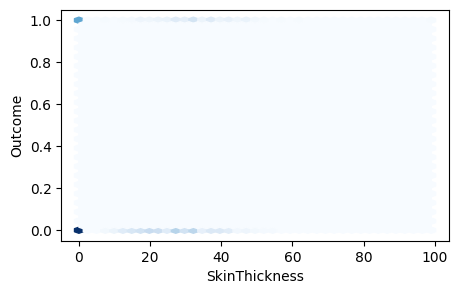

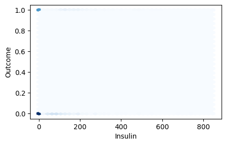

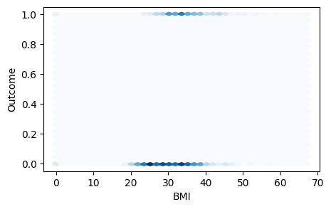

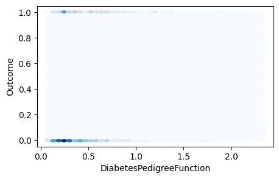

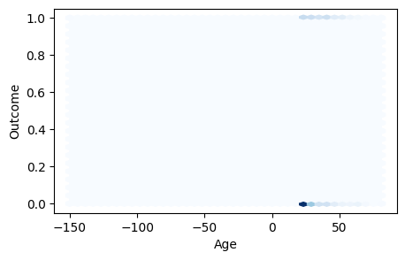

```python
for feature in diabetes:
    if feature != 'Outcome':
        plt.figure(figsize=(5, 3))
        plt.hexbin(diabetes[feature], diabetes['Outcome'], gridsize=40, cmap='Blues')
        plt.xlabel(feature)
        plt.ylabel('Outcome')
plt.show()
```

## Phase 1: Preprocessing

Q1:

Replace all missing values with the same value

Replace missing values with different values for each column

> These methods are used for categorical features, but it doesn’t factor the correlations between features and it can introduce bias in the data.

Replace missing values with mean, median, mode, etc. for each column

> This method is used for numerical values.

Replace missing values with previous/next valid values

> If method is set to 'ffill' or 'pad', missing values are replaced with previous valid values (= forward fill), and if 'bfill' or 'backfill', replaced with the next valid values (= backward fill).

Replace missing values with linear or spine interpolation by using interpolate()

> It accepts a wide variety of arguments, including, nearest, zero, slinear, quadratic, cubic, spline, barycentric, polynomial, krogh, piecewise_polynomial, spline, pchip, akima, cubicspline, etc.

Q2.

As we see the percentage of missing values in last part, DiabetesPedigreeFunction has the most NaN values with 23.17%. also SkinThickness and Pregnancies are in second and third place with 18.75% and 17.31%.

```python
for feature in diabetes.columns:
    if feature != 'Outcome' and feature != 'Pregnancies':
        diabetes[feature][diabetes[feature] <= 0] = np.nan
    elif feature == 'Pregnancies':
        diabetes[feature][diabetes[feature] < 0] = np.nan

diabetes.describe()
```

|  | Pregnancies | Glucose | SkinThickness | Insulin | BMI | DiabetesPedigreeFunction | Age | Outcome |
| --- | --- | --- | --- | --- | --- | --- | --- | --- |
| count | 633.000000 | 649.000000 | 438.000000 | 351.000000 | 675.000000 | 590.000000 | 654.000000 | 768.000000 |
| mean | 3.753555 | 122.000000 | 29.043379 | 155.225071 | 32.511407 | 0.466676 | 33.437309 | 0.348958 |
| std | 3.357769 | 30.798028 | 10.600092 | 119.458674 | 6.909103 | 0.322408 | 11.836619 | 0.476951 |
| min | 0.000000 | 44.000000 | 7.000000 | 14.000000 | 18.200000 | 0.078000 | 21.000000 | 0.000000 |
| 25% | 1.000000 | 99.000000 | 21.250000 | 76.000000 | 27.500000 | 0.243250 | 24.000000 | 0.000000 |
| 50% | 3.000000 | 117.000000 | 29.000000 | 126.000000 | 32.400000 | 0.368000 | 29.000000 | 0.000000 |
| 75% | 6.000000 | 141.000000 | 36.000000 | 190.000000 | 36.650000 | 0.611500 | 41.000000 | 1.000000 |
| max | 17.000000 | 199.000000 | 99.000000 | 846.000000 | 67.100000 | 2.329000 | 81.000000 | 1.000000 |

```python
diabetes.isnull().sum() * 100/len(diabetes)
```

```
Pregnancies                 17.578125
Glucose                     15.494792
SkinThickness               42.968750
Insulin                     54.296875
BMI                         12.109375
DiabetesPedigreeFunction    23.177083
Age                         14.843750
Outcome                      0.000000
dtype: float64
```

```python
diabetes.drop(columns=['Insulin', 'SkinThickness'], inplace=True)
diabetes
```

|  | Pregnancies | Glucose | BMI | DiabetesPedigreeFunction | Age | Outcome |
| --- | --- | --- | --- | --- | --- | --- |
| 0 | 6.0 | 148.0 | 33.6 | 0.627 | 50.0 | 1 |
| 1 | 1.0 | 85.0 | 26.6 | 0.351 | 31.0 | 0 |
| 2 | NaN | 183.0 | 23.3 | 0.672 | 32.0 | 1 |
| 3 | 1.0 | 89.0 | 28.1 | 0.167 | 21.0 | 0 |
| 4 | NaN | 137.0 | NaN | NaN | 33.0 | 1 |
| ... | ... | ... | ... | ... | ... | ... |
| 763 | 10.0 | 101.0 | 32.9 | NaN | 63.0 | 0 |
| 764 | 2.0 | 122.0 | 36.8 | 0.340 | NaN | 0 |
| 765 | 5.0 | NaN | 26.2 | 0.245 | 30.0 | 0 |
| 766 | 1.0 | 126.0 | 30.1 | 0.349 | NaN | 1 |
| 767 | NaN | 93.0 | 30.4 | 0.315 | 23.0 | 0 |

768 rows × 6 columns

Seperate X and y dataframes from the dataset:

```python
X, y = diabetes.drop(['Outcome'], axis=1, inplace=False) , diabetes['Outcome']
```

```python
for col in X.columns:
    X.fillna(X[col].median(), inplace=True)
X
```

|  | Pregnancies | Glucose | BMI | DiabetesPedigreeFunction | Age |
| --- | --- | --- | --- | --- | --- |
| 0 | 6.0 | 148.0 | 33.6 | 0.627 | 50.0 |
| 1 | 1.0 | 85.0 | 26.6 | 0.351 | 31.0 |
| 2 | 3.0 | 183.0 | 23.3 | 0.672 | 32.0 |
| 3 | 1.0 | 89.0 | 28.1 | 0.167 | 21.0 |
| 4 | 3.0 | 137.0 | 3.0 | 3.000 | 33.0 |
| ... | ... | ... | ... | ... | ... |
| 763 | 10.0 | 101.0 | 32.9 | 3.000 | 63.0 |
| 764 | 2.0 | 122.0 | 36.8 | 0.340 | 3.0 |
| 765 | 5.0 | 3.0 | 26.2 | 0.245 | 30.0 |
| 766 | 1.0 | 126.0 | 30.1 | 0.349 | 3.0 |
| 767 | 3.0 | 93.0 | 30.4 | 0.315 | 23.0 |

768 rows × 5 columns

```python
# X.drop(X[(X['Pregnancies'] < 0)].index, inplace=True)
# X.drop(X[(X['Glucose'] < 0)].index, inplace=True)
X.describe()
```

|  | Pregnancies | Glucose | BMI | DiabetesPedigreeFunction | Age |
| --- | --- | --- | --- | --- | --- |
| count | 768.000000 | 768.000000 | 768.000000 | 768.000000 | 768.000000 |
| mean | 3.621094 | 103.561198 | 28.937760 | 1.053827 | 28.919271 |
| std | 3.061460 | 51.555809 | 11.608657 | 1.106350 | 15.379807 |
| min | 0.000000 | 3.000000 | 3.000000 | 0.078000 | 3.000000 |
| 25% | 1.000000 | 88.000000 | 25.100000 | 0.263000 | 22.000000 |
| 50% | 3.000000 | 110.000000 | 30.900000 | 0.512000 | 27.000000 |
| 75% | 5.000000 | 136.000000 | 35.825000 | 1.326750 | 39.000000 |
| max | 17.000000 | 199.000000 | 67.100000 | 3.000000 | 81.000000 |

```python
X.isna().sum()
```

```
Pregnancies                 0
Glucose                     0
BMI                         0
DiabetesPedigreeFunction    0
Age                         0
dtype: int64
```

Q3.

**Numerical Encoding**

**Standardization**

Standardization (or Z-score normalization) is the process of rescaling the features so that they’ll have the properties of a Gaussian distribution with μ=0 and σ=1 where μ is the mean and σ is the standard deviation from the mean. Standard scores of the samples are calculated as follows:

$$ z = \frac{x - μ}{σ} $$

Standardization can be helpful in cases where the data follows a Gaussian distribution. However, this does not have to be necessarily true. Standardization does not have a bounding range. So, even if you have outliers in your data, they will not be affected by standardization.

**Normalization**

Normalization often also simply called Min-Max scaling basically shrinks the range of the data such that the range is fixed between 0 and 1 (or -1 to 1 if there are negative values). It works better for cases in which the standardization might not work so well. If the distribution is not Gaussian or the standard deviation is very small, the min-max scaler works better. Normalization is typically done via the following equation:

$$ X_{new} = \frac{X - X_{min}}{X_{max} - X_{min}} $$

Normalization is useful when there are no outliers as it cannot cope up with them like K-Nearest Neighbors and Neural Networks.

Normalizing the data is sensitive to outliers, so if there are outliers in the data set it is a bad practice. Standardization creates a new data not bounded. Since our values follow a guassian distribution, we use standardization method.

```python
for feature in X:
    scaled = preprocessing.StandardScaler().fit(X[[feature]])
    X[feature] = scaled.transform(X[[feature]])
X
```

|  | Pregnancies | Glucose | BMI | DiabetesPedigreeFunction | Age |
| --- | --- | --- | --- | --- | --- |
| 0 | 0.777556 | 0.862517 | 0.401879 | -0.386049 | 1.371569 |
| 1 | -0.856716 | -0.360256 | -0.201512 | -0.635680 | 0.135378 |
| 2 | -0.203007 | 1.541835 | -0.485968 | -0.345348 | 0.200441 |
| 3 | -0.856716 | -0.282620 | -0.072214 | -0.802101 | -0.515249 |
| 4 | -0.203007 | 0.649017 | -2.235802 | 1.760240 | 0.265503 |
| ... | ... | ... | ... | ... | ... |
| 763 | 2.084973 | -0.049711 | 0.341540 | 1.760240 | 2.217384 |
| 764 | -0.529862 | 0.357880 | 0.677715 | -0.645629 | -1.686378 |
| 765 | 0.450702 | -1.951802 | -0.235992 | -0.731553 | 0.070315 |
| 766 | -0.856716 | 0.435517 | 0.100184 | -0.637489 | -1.686378 |
| 767 | -0.203007 | -0.204983 | 0.126043 | -0.668241 | -0.385124 |

768 rows × 5 columns

Q4.

**Categotical Encoding**

- Label Encoding
- One-Hot Encoding

**Label Encoding** assigning each label to a unique integer based on alphabetical ordering.

> When categorical feature is ordinal or the number of categories is quite large so one-hot encoding can lead to high memory consumption

**One-Hot Encoding** adding new columns for each categorical value and assigining a binary vector to each row.

> When categorical feature is not ordinal or the number of categorical features is less so one-hot encoding can be effectively applied

Since our datas are numerical and we do not have any categorical data, so we don't need to use these two.

Q5.

Q6.

In the context of Machine Learning, we split our modelling dataset into training and testing samples. The creation of different samples for training and testing helps us evaluate model performance and void overfitting. ome common inferences that can be derived on dataset split include:

If there are multiple meta-parameters to tune, the machine learning model will need a larger validation set to optimize the model's performance. Similarly, if the model has fewer or no hyperparameters, it will be easy to validate the model using a small set of data.

The truth is There is no optimal split percentage.

One has to come to a split percentage that suits the requirements and meets the model’s needs.

However, there are two things to keep in mind when splitting the data:

1. If there is less training data, the machine learning model will show high variance in training.
2. With less testing data/validation data, your model evaluation/model performance statistic will have greater variance.

Random sampling is the oldest and most popular method for dividing a dataset. As the name suggests, the dataset is shuffled, and samples are picked randomly and put in the train, validation, or the test set based on what percentage ratio is given by the user.

Stratified sampling preserve the distribution of classes in each of the train, validation, and test sets.

Stratified sampling is, thus, a more fair way of data splitting, such that the machine learning model will be trained and validated on the same data distribution.

Q7.

The original data in a machine learning model is typically taken and split into three or four sets. The three sets commonly used are the training set, the dev set and the testing set:

The **training set** is the portion of data used to train the model. The model should observe and learn from the training set, optimizing any of its parameters.

The **validation set** is a set of data, separate from the training set, that is used to validate our model performance during training. This validation process gives information that helps us tune the model’s hyperparameters and configurations accordingly. It is like a critic telling us whether the training is moving in the right direction or not. The model is trained on the training set, and, simultaneously, the model evaluation is performed on the validation set after every epoch. The main idea of splitting the dataset into a validation set is to prevent our model from overfitting i.e., the model becomes really good at classifying the samples in the training set but cannot generalize and make accurate classifications on the data it has not seen before.

The **testing set** is the portion of data that is tested in the final model and is compared against the previous sets of data. The testing set acts as an evaluation of the final mode and algorithm.

## Phase 2: Model Training, Evaluation and Hyper Parameter Tuning

```python
from sklearn.model_selection import train_test_split

X_train, X_test, y_train, y_test = train_test_split(X, y, random_state=6, test_size=0.2)
print ('Train set:', X_train.shape,  y_train.shape)
print ('Test set:', X_test.shape,  y_test.shape)
```

```
Train set: (614, 5) (614,)
Test set: (154, 5) (154,)
```

- ### K Nearest Neighbors

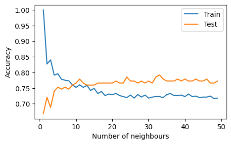

```python
from sklearn.metrics import classification_report, ConfusionMatrixDisplay, accuracy_score
from sklearn.neighbors import KNeighborsClassifier
neighbours = range(1, 50)

test = []
train = []

for i in neighbours:
    knn = KNeighborsClassifier(n_neighbors=i)
    knn.fit(X_train,y_train)

    train_pred= knn.predict(X_train)
    train.append(accuracy_score(y_train, train_pred))

    test_pred = knn.predict(X_test)
    test.append(accuracy_score(y_test, test_pred))

plt.figure(figsize=(5, 3))
plt.plot(neighbours, train, label='Train')
plt.plot(neighbours, test, label='Test')
plt.xlabel('Number of neighbours')
plt.ylabel('Accuracy')
plt.legend()
plt.show()
```

```python
knn = KNeighborsClassifier(n_neighbors=33)
knn.fit(X_train,y_train)
```

```
KNeighborsClassifier(n_neighbors=33)
```

```python
predKnn = knn.predict(X_test)
print(predKnn[0:5])
print(y[:5].values)
```

```
[0 0 0 0 0]
[1 0 1 0 1]
```

```python
from sklearn import metrics
print("K-Nearest-Neighbor's Train Accuracy: ", metrics.accuracy_score(y_train, knn.predict(X_train)))
print("K-Nearest-Neighbor's Test Accuracy: ", metrics.accuracy_score(y_test, predKnn))
```

```
K-Nearest-Neighbor's Train Accuracy:  0.7231270358306189
K-Nearest-Neighbor's Test Accuracy:  0.7922077922077922
```

- ### Desicion Tree

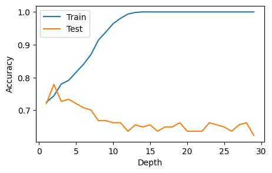

```python
from sklearn.tree import DecisionTreeClassifier

depths = range(1, 30)

test = []
train = []

for i in depths:
    tree = DecisionTreeClassifier(max_depth=i)
    tree.fit(X_train,y_train)

    train_pred= tree.predict(X_train)
    train.append(accuracy_score(y_train, train_pred))

    test_pred = tree.predict(X_test)
    test.append(accuracy_score(y_test, test_pred))

plt.figure(figsize=(5, 3))
plt.plot(depths, train, label='Train')
plt.plot(depths, test, label='Test')
plt.xlabel('Depth')
plt.ylabel('Accuracy')
plt.legend()
plt.show()
```

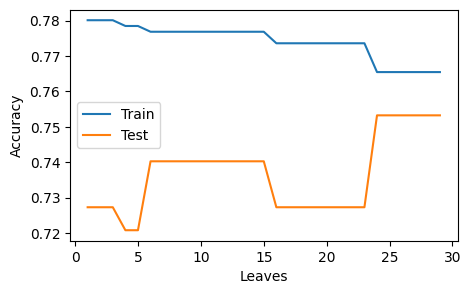

```python
leaves = range(1, 30)

test = []
train = []

for i in leaves:
    tree = DecisionTreeClassifier(max_depth=3, min_samples_leaf=i)
    tree.fit(X_train,y_train)

    train_pred= tree.predict(X_train)
    train.append(accuracy_score(y_train, train_pred))

    test_pred = tree.predict(X_test)
    test.append(accuracy_score(y_test, test_pred))

plt.figure(figsize=(5, 3))
plt.plot(leaves, train, label='Train')
plt.plot(leaves, test, label='Test')
plt.xlabel('Leaves')
plt.ylabel('Accuracy')
plt.legend()
plt.show()
```

```python
tree = DecisionTreeClassifier(max_depth=2, min_samples_leaf=24)
tree.fit(X_train,y_train)
```

```
DecisionTreeClassifier(max_depth=2, min_samples_leaf=24)
```

```python
predTree = tree.predict(X_test)
print (predTree [0:5])
print (y_test [0:5].values)
```

```
[0 0 0 0 0]
[0 1 0 0 0]
```

```python
print("DecisionTrees's Train Accuracy: ", metrics.accuracy_score(y_train, tree.predict(X_train)))
print("DecisionTrees's Test Accuracy: ", metrics.accuracy_score(y_test, predTree))
```

```
DecisionTrees's Train Accuracy:  0.7328990228013029
DecisionTrees's Test Accuracy:  0.7922077922077922
```

- ### Logistic Regression

```python
from sklearn.linear_model import LogisticRegression

LR = LogisticRegression()
LR.fit(X_train,y_train)
```

```
LogisticRegression()
```

```python
predLR = LR.predict(X_test)
print(predLR[:5])
print(y_test[:5].values)
```

```
[0 0 0 0 0]
[0 1 0 0 0]
```

```python
print("Logistic Regression's Train Accuracy: ", metrics.accuracy_score(y_train, LR.predict(X_train)))
print("Logistic Regression's Test Accuracy: ", metrics.accuracy_score(y_test, predLR))
```

```
Logistic Regression's Train Accuracy:  0.7198697068403909
Logistic Regression's Test Accuracy:  0.7792207792207793
```

Q1.

$True Positive:$

Interpretation: You predicted positive and it’s true.

You predicted that a woman is pregnant and she actually is.

$True Negative:$

Interpretation: You predicted negative and it’s true.

You predicted that a man is not pregnant and he actually is not.

$False Positive: (Type 1 Error)$

Interpretation: You predicted positive and it’s false.

You predicted that a man is pregnant but he actually is not.

$False Negative: (Type 2 Error)$

Interpretation: You predicted negative and it’s false.

You predicted that a woman is not pregnant but she actually is.

```
<sklearn.metrics._plot.confusion_matrix.ConfusionMatrixDisplay at 0x2439023bfd0>
```

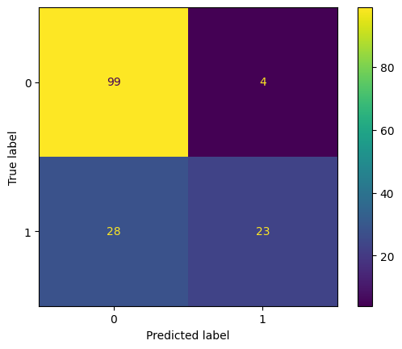

```python
ConfusionMatrixDisplay.from_predictions(y_test, predKnn)
```

```
<sklearn.metrics._plot.confusion_matrix.ConfusionMatrixDisplay at 0x2438c3b44c0>
```

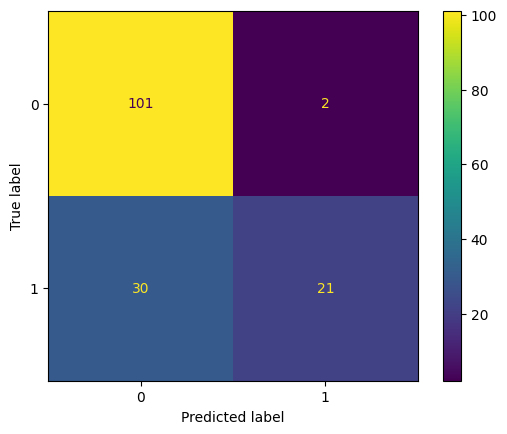

```python
ConfusionMatrixDisplay.from_predictions(y_test, predTree)
```

```
<sklearn.metrics._plot.confusion_matrix.ConfusionMatrixDisplay at 0x2438e67a790>
```

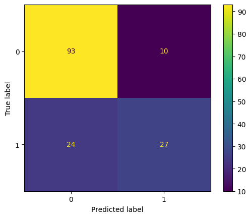

```python
ConfusionMatrixDisplay.from_predictions(y_test, predLR)
```

Q2.

```python
from sklearn.model_selection import GridSearchCV
```

```python
param_dict = {
    'n_neighbors': range(1, 50),
    'weights': ['uniform', 'distance'],
    'algorithm': ['auto', 'ball_tree', 'kd_tree', 'brute'],
    'leaf_size': range(1, 5),
    'p': [1, 2]
}
grid_knn = GridSearchCV(knn, param_dict, cv=10, scoring='accuracy', verbose = 1, n_jobs=-1)
grid_knn.fit(X_train, y_train)
```

```
Fitting 10 folds for each of 3136 candidates, totalling 31360 fits
```

```
GridSearchCV(cv=10, estimator=KNeighborsClassifier(n_neighbors=33), n_jobs=-1,
             param_grid={'algorithm': ['auto', 'ball_tree', 'kd_tree', 'brute'],
                         'leaf_size': range(1, 5), 'n_neighbors': range(1, 50),
                         'p': [1, 2], 'weights': ['uniform', 'distance']},
             scoring='accuracy', verbose=1)
```

```python
print(grid_knn.best_params_)
print(grid_knn.score(X_train, y_train))
print(grid_knn.score(X_test, y_test))
```

```
{'algorithm': 'auto', 'leaf_size': 1, 'n_neighbors': 4, 'p': 1, 'weights': 'uniform'}
0.8029315960912052
0.7402597402597403
```

```python
param_dict = {
    'criterion': ['gini', 'entropy'],
    'max_depth': range(1, 10),
    'min_samples_split': range(2, 10),
    'min_samples_leaf': range(1, 5)
}
grid_tree = GridSearchCV(tree, param_dict, cv=10, scoring='accuracy', verbose=1, n_jobs=-1)
grid_tree.fit(X_train, y_train)
```

```
Fitting 10 folds for each of 576 candidates, totalling 5760 fits
```

```
GridSearchCV(cv=10,
             estimator=DecisionTreeClassifier(max_depth=2, min_samples_leaf=24),
             n_jobs=-1,
             param_grid={'criterion': ['gini', 'entropy'],
                         'max_depth': range(1, 10),
                         'min_samples_leaf': range(1, 5),
                         'min_samples_split': range(2, 10)},
             scoring='accuracy', verbose=1)
```

```python
print(grid_tree.best_params_)
print(grid_tree.score(X_train, y_train))
print(grid_tree.score(X_test, y_test))
```

```
{'criterion': 'gini', 'max_depth': 3, 'min_samples_leaf': 3, 'min_samples_split': 2}
0.7801302931596091
0.7467532467532467
```

```python
grid_logistic={
    'C' : np.logspace(-3,3,7),
    'penalty' : ["l1","l2"]
}
grid_logistic = GridSearchCV(LR, grid_logistic, cv=10, scoring='accuracy', verbose=1, n_jobs=-1)
grid_logistic.fit(X_train, y_train)
```

```
Fitting 10 folds for each of 14 candidates, totalling 140 fits
```

```
GridSearchCV(cv=10, estimator=LogisticRegression(), n_jobs=-1,
             param_grid={'C': array([1.e-03, 1.e-02, 1.e-01, 1.e+00, 1.e+01, 1.e+02, 1.e+03]),
                         'penalty': ['l1', 'l2']},
             scoring='accuracy', verbose=1)
```

```python
print(grid_logistic.best_params_)
print(grid_logistic.score(X_test, y_test))
```

```
{'C': 10.0, 'penalty': 'l2'}
0.7792207792207793
```

Q3.

**Overfitting** happens when a model learns the detail and noise in the training data to the extent that it negatively impacts the performance of the model on new data. This means that the noise or random fluctuations in the training data is picked up and learned as concepts by the model. The problem is that these concepts do not apply to new data and negatively impact the models ability to generalize.

**Underfitting** refers to a model that can neither model the training data nor generalize to new data. An underfit machine learning model is not a suitable model and will be obvious as it will have poor performance on the training data.

## Phase 3: Ensemble Methods

Q1.

**max_depth:** The max_depth of a tree in Random Forest is defined as the longest path between the root node and the leaf node.

**min_sample_split:** A parameter that tells the decision tree in a random forest the minimum required number of observations in any given node in order to split it.

**max_leaf_nodes:** This hyperparameter sets a condition on the splitting of the nodes in the tree and hence restricts the growth of the tree.

**min_samples_leaf:** This hyperparameter specifies the minimum number of samples that should be present in the leaf node after splitting a node.

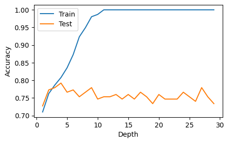

```python
from sklearn.ensemble import RandomForestClassifier

depths = range(1, 30)

test = []
train = []

for i in depths:
    forest = RandomForestClassifier(max_depth=i)
    forest.fit(X_train,y_train)

    train_pred= forest.predict(X_train)
    train.append(accuracy_score(y_train, train_pred))

    test_pred = forest.predict(X_test)
    test.append(accuracy_score(y_test, test_pred))

plt.figure(figsize=(5, 3))
plt.plot(depths, train, label='Train')
plt.plot(depths, test, label='Test')
plt.xlabel('Depth')
plt.ylabel('Accuracy')
plt.legend()
plt.show()
```

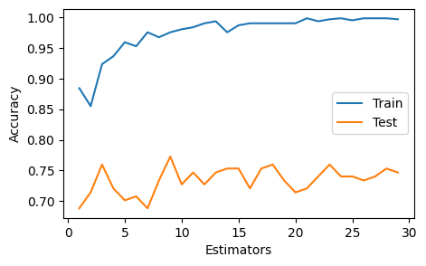

```python
estimators = range(1, 30)

test = []
train = []

for i in estimators:
    forest = RandomForestClassifier(max_depth=13, n_estimators=i)
    forest.fit(X_train,y_train)

    train_pred= forest.predict(X_train)
    train.append(accuracy_score(y_train, train_pred))

    test_pred = forest.predict(X_test)
    test.append(accuracy_score(y_test, test_pred))

plt.figure(figsize=(5, 3))
plt.plot(estimators, train, label='Train')
plt.plot(estimators, test, label='Test')
plt.xlabel('Estimators')
plt.ylabel('Accuracy')
plt.legend()
plt.show()
```

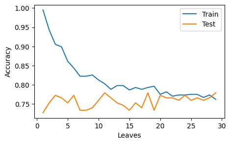

```python
leaves = range(1, 30)

test = []
train = []

for i in leaves:
    forest = RandomForestClassifier(max_depth=13, n_estimators=17, min_samples_leaf=i)
    forest.fit(X_train,y_train)

    train_pred= forest.predict(X_train)
    train.append(accuracy_score(y_train, train_pred))

    test_pred = forest.predict(X_test)
    test.append(accuracy_score(y_test, test_pred))

plt.figure(figsize=(5, 3))
plt.plot(leaves, train, label='Train')
plt.plot(leaves, test, label='Test')
plt.xlabel('Leaves')
plt.ylabel('Accuracy')
plt.legend()
plt.show()
```

```python
random_forest = RandomForestClassifier(max_depth=12, n_estimators=17, min_samples_leaf=27)
random_forest.fit(X_train,y_train)
```

```
RandomForestClassifier(max_depth=12, min_samples_leaf=27, n_estimators=17)
```

```python
predForest = random_forest.predict(X_test)
print(predForest[:5])
print(y_test[:5].values)
```

```
[0 0 0 0 0]
[0 1 0 0 0]
```

```python
print("Forest's Accuracy: ", metrics.accuracy_score(y_test, predForest))
```

```
Forest's Accuracy:  0.7662337662337663
```

```python
from mlxtend.evaluate import bias_variance_decomp
```

```python
param_dict = {
    'criterion': ['gini', 'entropy'],
    'max_depth': [None, 1, 10, 20],
    'min_samples_split': [1, 2, 5, 10],
    'min_samples_leaf': [1, 2, 5, 10],
}
grid_forest = GridSearchCV(random_forest, param_dict, cv=10, scoring='accuracy', verbose=1, n_jobs=-1)
grid_forest.fit(X_train, y_train)
```

```
Fitting 10 folds for each of 128 candidates, totalling 1280 fits
```

[output not shown]

[output cut: 8 more lines]

[output not shown]

```
GridSearchCV(cv=10,
             estimator=RandomForestClassifier(max_depth=12, min_samples_leaf=27,
                                              n_estimators=17),
             n_jobs=-1,
             param_grid={'criterion': ['gini', 'entropy'],
                         'max_depth': [None, 1, 10, 20],
                         'min_samples_leaf': [1, 2, 5, 10],
                         'min_samples_split': [1, 2, 5, 10]},
             scoring='accuracy', verbose=1)
```

```python
print(grid_forest.best_params_)
print(grid_forest.score(X_test, y_test))
```

```
{'criterion': 'gini', 'max_depth': None, 'min_samples_leaf': 5, 'min_samples_split': 10}
0.7597402597402597
```

```python
random_forest = RandomForestClassifier(max_depth=10, n_estimators=23, min_samples_leaf=2)
random_forest.fit(X_train,y_train)
predForest = random_forest.predict(X_test)
```

```
<sklearn.metrics._plot.confusion_matrix.ConfusionMatrixDisplay at 0x2438e74aa60>
```

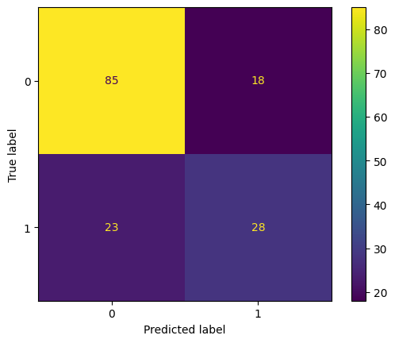

```python
ConfusionMatrixDisplay.from_predictions(y_test, predForest)
```

Q2.

```python
avg_expected_loss, avg_bias, avg_var = bias_variance_decomp(
        random_forest, X_train.values, y_train.values, X_test.values, y_test.values,
        random_seed=1)

print('Random_forest bias: %.3f' % avg_bias)
print('Random_forest variance: %.3f' % avg_var)
```

```
Random_forest bias: 0.247
Random_forest variance: 0.100
```

```python
tree = DecisionTreeClassifier(max_depth=2, min_samples_leaf=1, min_samples_split=2, criterion='entropy')
tree.fit(X_train,y_train)
predTree = tree.predict(X_test)
```

```python
avg_expected_loss, avg_bias, avg_var = bias_variance_decomp(
       tree, X_train.values, y_train.values, X_test.values, y_test.values,
        random_seed=1)

print('Average bias: %.3f' % avg_bias)
print('Average variance: %.3f' % avg_var)
```

```
Average bias: 0.227
Average variance: 0.107
```